# My Individual Project

Alex Emert

# Initial Goals

- build confidence in R and other R packages
- learn more about mtg booster pack and commander data
- Use an API??

# Where I started

I started by looking at the Scryfall R package, which is kind of like a built in API.

-`scryr`: uses function `scry_cards()` to find magic cards that fit the search

Uses scryfall search terms, not R’s. Makes it more confusing to find certain cards as it uses it’s own syntax.

# Next Steps

Then, I looked at the MTGJSON data, which both has an API and downloadable files of all MTG cards.

The raw data included over 15 csvs worth of data, some of which had ~200,000 rows.

# Ideas that I got from there

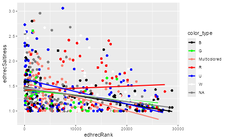

Commander Popularity/Dislike by color

# Another direction I could have gone

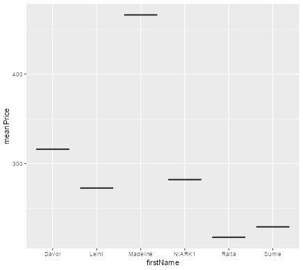

Highest average card value by Artist first name

# Developing the project

Goal:

- Shiny app that can simulate opening a bunch of booster packs, and show you the distribution of total pack price
- show example pack from linked card image data (scyr search)

# The Process

Where things went wrong

Some sets that were smaller had errors due to different real-life booster pack sizes, or inconsistent data from 20+ years of changes to card creation

# Example of correct graph from simulated boosters

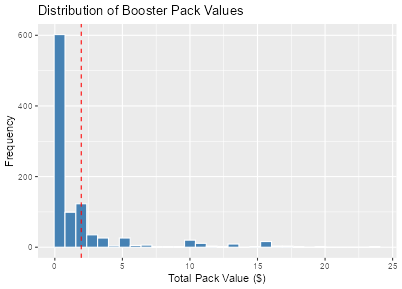

Where things went right

# RESULTS

- In the end, the app kind of worked but only for certain sets
- Any errors are most likely due to data cleaning which I struggled with given the size of the data
- Was not able to show example pack opening due to limitations between scryr and MTGJSON data

# What I would do differently next time (lessons)

- Better time management (choose more specific topic/goal sooner and commit to it)
- Start smaller and then work my way up to a project that I can finish in time
- Much more data wrangling a.k.a. get the boring stuff out of the way earlier